# Reproducible Research: Peer Assessment 1

This document describes the details of analysis of a study tracking the number of steps taken by the study subject over the course of 2 months. The data is located in a *.csv file entitled activity.csv. It was downloaded on Oct 13, 2014 from the Coursera course website for the course Reproducible Research.

The variables included in this dataset are:

steps: Number of steps taking in a 5-minute interval (missing values are coded as NA)

date: The date on which the measurement was taken in YYYY-MM-DD format

interval: Identifier for the 5-minute interval in which measurement was taken

There are a total of 17,568 observations in this dataset.

## Loading and preprocessing the data

The data was loaded into R and then processed into two processed datasets: t - setting up individual columns for each date and rows for the time intervals t2 - setting up individual columns for each time interval and rows for the dates The two data sets will be used separately in the below analysis. This analysis requires the *reshape* and *plyr* packages

```r
require(reshape)
require(plyr)
require(xtable)
## Load the data & preprocess as necessary
dat <-read.csv(file='activity.csv')
#set up columns for each date with values of steps for each interval
t<-cast(dat,interval~date,value="steps")
# set up columns for each interval with values for steps for each date
t2<-cast(dat,date~interval,value="steps")
```

## What is mean total number of steps taken per day?

To calculate the mean number of steps per day, we first calculate the sum for each day and then examine a histogram of the number of steps per day:

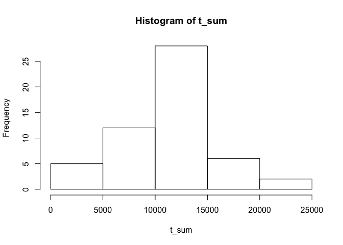

```r
t_sum<-colSums(t,na.rm=FALSE)
hist(t_sum)
```

After this examination, we calculate the **mean** and **median** of the number of steps per day. In these calculations, the days with missing values were ignored.

```r
t_mean <- mean(t_sum,na.rm=TRUE)
t_median <-median(t_sum,na.rm=TRUE)
```

The analysis determined that mean number of steps is 1.0766 × 10<sup>4</sup> and the median number of steps is 1.0765 × 10<sup>4</sup>.

## What is the average daily activity pattern?

To find the average daily activity pattern, use the **t2** cast data set which collected the time intervals in columns and the daily data as rows.  
Calculate a vector of column means (t2_mean) and then set up the plot characteristics to generate the time series of means across each time interval.

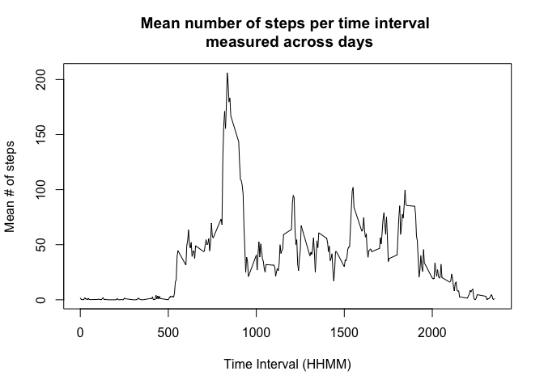

```r
## find colmeans
t2_mean <-colMeans(t2,na.rm=TRUE)
## set value for x axis and the plot characteristics
x_int <-as.integer(names(t2)[-1])
title<-c("Mean number of steps per time interval \n measured across days")
yl<-c("Mean # of steps")
xl<-c("Time Interval (HHMM)")
plot(x_int,t2_mean,type="l",xlab=xl,ylab=yl,main=title)
```

Within the set of means, the maximum value is determined by pulling the maximum value from the *t2_mean* vector.

```r
## Which 5-min interval, on average across all days, contains max # of steps?
max_steps_interval<-names(which(t2_mean == max(t2_mean)))
```

The early morning interval beginning at 835 was found to have the largest average steps per interval.

## Data processing to handle missing values

The next stage of the analysis was to determine a method for handling missing values within the dataset. As a first step, determine the number (and location) of rows with missing values.

```r
## Calc & report total # of missing values in dataset (ie total rows with NAs)
rows_na <- apply(t2, 1, function(x){any(is.na(x))})
num_rows_na <- sum(rows_na) ## report this in text
```

The vector *rows_na* is a logical vector storing T/F for each row with T meaning the row contains missing values. The total number of rows found is 8.

To deal with the missing data, replace the row entries with missing values with the integer mean value of the steps for that time interval across all remaining, non-missing days.

```r
## impute the missing data (describe the strategy)
## use the integer mean value of the steps for each time interval to replace NAs
## create new dataset with data imputed
tImpute<-t2
tImpute[rows_na,2:289]<-as.integer(t2_mean)
```

A question arises as to how this treatment of the missing values effects the overall analysis. To determine the answer for this question, re-create the analysis of the dataset with ignored missing values on the imputed dataset. First find totals for each day (here stored in rows) and plot a histogram:

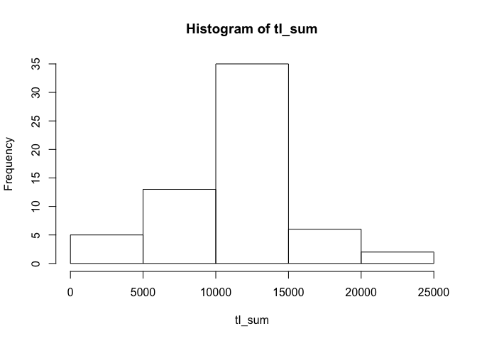

```r
## make hist of total # steps taken each day
tI_sum<-rowSums(tImpute)
hist(tI_sum)
```

Next, compute the **mean** and **median** for the imputed dataset and compare to results from original analysis:

```r
## Do these values differ from the estimates from the first part of the assignment?
## What is the impact of the imputation?
tI_mean <- mean(tI_sum)
tI_median <-median(tI_sum)
```

The analysis determined that mean number of steps is 1.075 × 10<sup>4</sup> and the median number of steps is 1.0632 × 10<sup>4</sup> for the imputed data set. Comparing with the original analysis shows the following:

```r
## create data for table export
tI_m<-c(tI_mean,tI_median)
t_m<-c(t_mean,t_median)
xtab<-data.frame(rbind(tI_m,t_m),row.names=c("Imputed Data","Drop Missing Data"))
names(xtab)<-c("Mean","Median")
xt<-xtable(xtab)
print(xt, type="html")
```

|  | Mean | Median |
| --- | --- | --- |
| Imputed Data | 10749.77 | 10632.00 |
| Drop Missing Data | 10766.19 | 10765.00 |

The inclusion of the missing data rows imputed with the mean value for each interval makes minor changes to the Mean (as expected using the mean for the imputation value) and an approximately 1.2% change in the Median values which is again not signficant.

## Are there differences in activity patterns between weekdays and weekends?

```r
## using imputed data set
## create factor variable with two levels: weekday, weekend
tImpute_days <-weekdays(as.Date(tImpute$date))
tImpute_days <-revalue(tImpute_days,c("Monday"="weekday","Tuesday"="weekday",
                           "Wednesday"="weekday","Thursday"="weekday",
                           "Friday"="weekday","Saturday"="weekend","Sunday"="weekday"))
tImpute<-cbind(tImpute,tImpute_days)
```

The plot will use the newly created variable and calculated means for each time interval across all days in the Imputed data set (tImpute).

```r
## make a panel plot containing a time series of 5-min interval v aver # of
## steps taken, averaged across all weekdays and weekend days
tI_mday<-colMeans(tImpute[tImpute$tImpute_days=="weekday",2:289])
tI_mend<-colMeans(tImpute[tImpute$tImpute_days=="weekend",2:289])
```

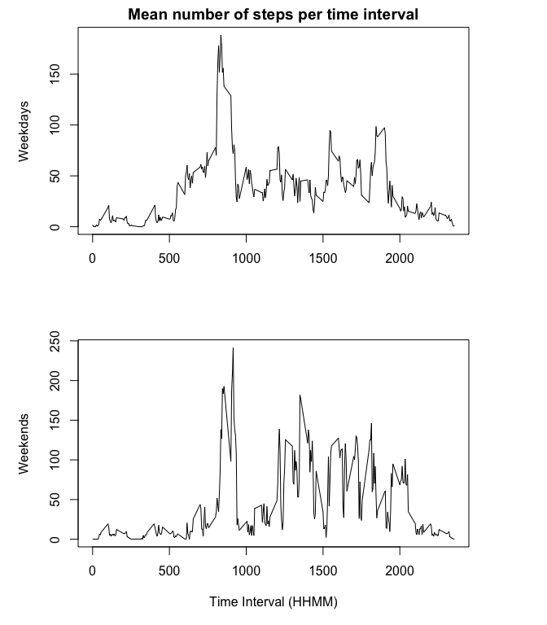

```r
par(mfrow=c(2,1),mai=c(1,1,0.35,1))
title<-c("Mean number of steps per time interval")
yl<-c("Mean # of steps")
xl<-c("Time Interval (HHMM)")
plot(x_int,tI_mday,type="l",xlab="",ylab="Weekdays",main=title)
plot(x_int,tI_mend,type="l",xlab=xl,ylab="Weekends")
```